# Homework 4

Shangjun Jiang

Due: 11:59pm Tuesday, July 5, 2016

## Github

Just a friendly reminder that your Github accounts should be up-to-date. By the end of this assignment, you should have `hw1`-`hw4` folders filled along with `labs1`-`labs4` folders. `labs4` will have `lab13` and `lab14` in it.

## knitr

As you try to reproduce this document, you may need to resize your graphs. This is an art form that will require trial-and-error. It’s a pain to do in any document creation process. [The R markdown chunk settings can be found at this link](http://yihui.name/knitr/options/). The options go in the same place that you’ve been using `echo` and `eval`, and are separated by commas.

## Allowed Packages:

The following packages are allowed for this assignment:

- readr
- stringr
- dplyr
- tidyr
- lubridate
- ggplot2

```r
library(dplyr)
library(tidyr)
library(readr)
library(stringr)
library(lubridate)
```

```r
library(ggplot2)
library(ggrepel)
library(grid)
library(gridExtra)
```

## The Data

[The data come from a bike-renting program, CapitalShare, in Washington, DC](https://www.capitalbikeshare.com/data/stations/bikeStations.xml). Cases span the last quarter of 2014.

Two data files are available:

- `dc_stations.csv` has the locations of bike rental stations
  - `name` - name of the station
  - `lat` - latitude of the station
  - `long` - longitude of the station
  - `nbBikes` - the number of bicycles currently docked at this station at time of data retrieval. Irrelevant for this lab
  - `nbEmptyDocks` - the number of empty docks at the time of data retrieval. Irrelevant for this lab
- `2014q4_trips.csv` is a 653763 observation data set containing individual bike rental information.
  - `duration` - length of the trip
  - `sdate` - timestamp for start of the rental
  - `sstation` - station of bike rental
  - `edate` - timestamp for end of rental
  - `estation` - station of bike return
  - `bikeno` - unique bike ID
  - `client` - registered clients have a subscription whereas casual users do not

```r
station <- read.csv("dc_stations.csv")
str(station)
```

```
## 'data.frame':    347 obs. of  5 variables:
##  $ name        : Factor w/ 347 levels "10th & E St NW",..: 67 49 68 33 135 285 311 176 11 86 ...
##  $ lat         : num  38.9 38.9 38.9 38.9 38.9 ...
##  $ long        : num  -77.1 -77.1 -77 -77 -77.1 ...
##  $ nbBikes     : int  7 8 8 9 7 7 5 5 6 14 ...
##  $ nbEmptyDocks: int  4 3 7 2 4 12 6 13 5 5 ...
```

```r
trips <- read.csv("2014q4_trips.csv")
str(trips)
```

```
## 'data.frame':    653763 obs. of  7 variables:
##  $ duration: Factor w/ 10355 levels "0h 0m 0s","0h 0m 10s",..: 89 2686 6991 2020 743 3350 264 456 2670 3315 ...
##  $ sdate   : Factor w/ 101318 levels "2014-10-01T00:00:00Z",..: 1 2 3 2 4 5 6 7 7 8 ...
##  $ sstation: Factor w/ 347 levels "10th & E St NW",..: 347 165 283 72 247 26 76 169 101 43 ...
##  $ edate   : Factor w/ 101211 levels "2014-10-01T00:05:00Z",..: 3 2 25 1 8 3 6 7 4 5 ...
##  $ estation: Factor w/ 347 levels "10th & E St NW",..: 43 107 332 43 82 119 106 197 101 326 ...
##  $ bikeno  : Factor w/ 3119 levels "W00005","W00006",..: 1857 1843 66 1131 672 2163 2803 2717 2414 2324 ...
##  $ client  : Factor w/ 2 levels "Casual","Registered": 2 2 1 2 2 2 2 2 2 2 ...
```

## Time of Day (20 points)

One might suspect that bike rentals are more popular at certain times of day than others. Explore this idea by creating the graph below, titles and all. The time of day refers to the timestamp of the start of the rental. No special text size formatting was done, but if you decide to do so, no points will be awarded/lost.

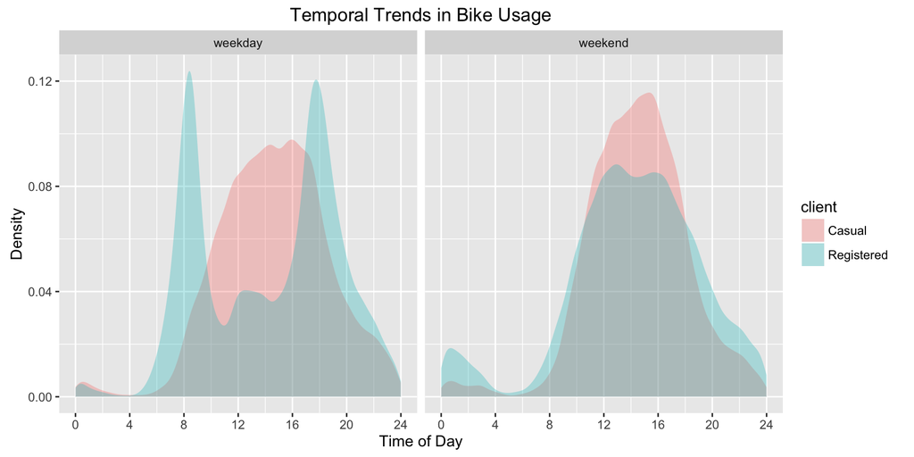

```r
# <Your Code>

st <-str_match(trips$sdate,"[0-9]{2}:[0-9]{2}:[0-9]{2}")
st<- hms(st)
trips <- mutate(trips, stduration= (hour(st) + minute(st)/60))

#get weekday or weekend.
#trips <- mutate(trips, sdate = as.numeric(trips$sdate))
trips <- mutate(trips, wd = (wday(trips$sdate)))
trips <- mutate(trips, wd = ifelse (trips$wd>6 | trips$wd <2, "weekend", "weekday"))


ggplot(trips,aes(x = stduration,y = ..density..))+
  geom_density(aes(fill=client),alpha = 0.3, color = NA)+
  facet_wrap(~wd)+
  scale_x_continuous(limits = c(0, 24), breaks = seq(0, 24, by = 4))+
  labs(title = "Temporal Trends in Bike Usage",
       x = "Time of Day",
       y = "Density")
```

Hints:

1. You may want to convert the time to a numeric value ranging from 0-24.
2. Alpha was set to 0.3.
3. Setting color/fill to `NA` removes that aesthetic altogether.
4. Use `scale_x_continuous` to modify the x-axis scale.

## Distance (20 points)

Bikeshare members may behave differently than casual renters. Here we look at how their start and end stations differ in terms of crude distances. Create the graph below, titles and all. Distance is measured as the haversine between two stations (see note below). Distances of more than 10km have been filtered out.

```r
# <Your code>

#crossing
cs <- crossing(station,station)
#str(cs)
cs$nbBikes<- NULL
cs$nbEmptyDocks <- NULL
cs$nbBikes<- NULL
cs$nbEmptyDocks <- NULL
length(cs$name)
```

```
## [1] 120409
```

```r
names(cs) <- c("sstation", "slat", "slong", "estation", "elat", "elong")
iii<- inner_join(cs,trips)
#str(iii)

# create a sstation & estation

# harvesine
source("haversine.R")
iii<- mutate(iii, distance= with(iii, haversine (slat,slong,elat,elong)))
str(iii)
```

```
## Classes 'tbl_df', 'tbl' and 'data.frame':    649972 obs. of  14 variables:
##  $ sstation  : chr  "20th & Bell St" "20th & Bell St" "20th & Bell St" "20th & Bell St" ...
##  $ slat      : num  38.9 38.9 38.9 38.9 38.9 ...
##  $ slong     : num  -77.1 -77.1 -77.1 -77.1 -77.1 ...
##  $ estation  : chr  "20th & Bell St" "20th & Bell St" "20th & Bell St" "20th & Bell St" ...
##  $ elat      : num  38.9 38.9 38.9 38.9 38.9 ...
##  $ elong     : num  -77.1 -77.1 -77.1 -77.1 -77.1 ...
##  $ duration  : Factor w/ 10355 levels "0h 0m 0s","0h 0m 10s",..: 64 3269 11 177 126 626 4288 42 34 23 ...
##  $ sdate     : Factor w/ 101318 levels "2014-10-01T00:00:00Z",..: 365 2930 9797 13453 28700 29934 34853 37390 41385 48418 ...
##  $ edate     : Factor w/ 101211 levels "2014-10-01T00:05:00Z",..: 365 2991 9801 13469 28695 29930 34906 37375 41367 48397 ...
##  $ bikeno    : Factor w/ 3119 levels "W00005","W00006",..: 2481 2013 1757 2497 1433 1390 1578 1417 2355 2547 ...
##  $ client    : Factor w/ 2 levels "Casual","Registered": 2 1 2 2 1 2 2 2 2 2 ...
##  $ stduration: num  10.2 12.67 8.52 11.17 13.07 ...
##  $ wd        : chr  "weekday" "weekday" "weekday" "weekend" ...
##  $ distance  : num  0 0 0 0 0 0 0 0 0 0 ...
```

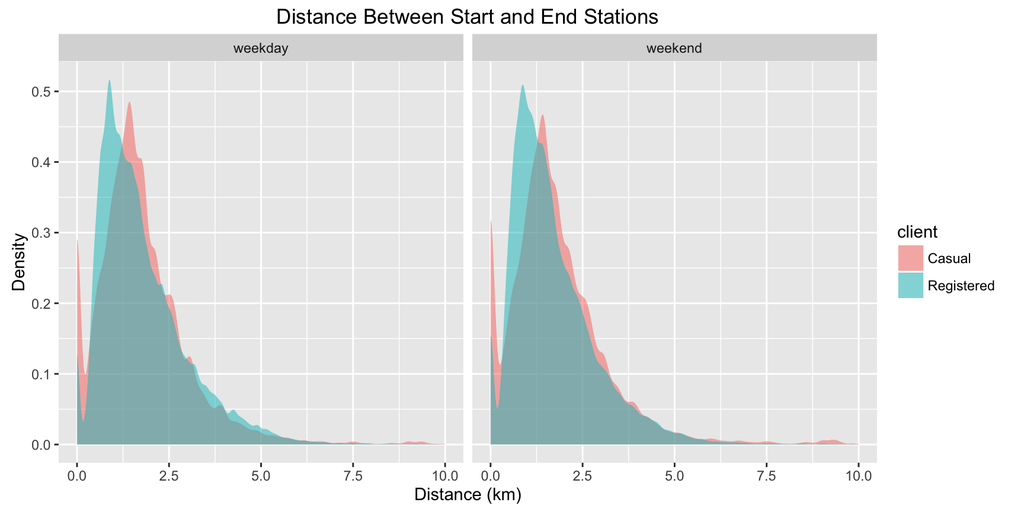

```r
ggplot(iii,aes(x = distance,y = ..density..))+
  geom_density(aes(fill=client), alpha = 0.5, color = NA)+
  facet_wrap(~wd)+
  scale_x_continuous(limits = c(0.0, 10.0), breaks = seq(0.0, 10.0, by = 2.5))+
  labs(title = "Distance Between Start and End Stations",
       x = "Distance (km)",
       y = "Density")
```

Hint:

1. You’ll need to create a data frame with `start` and `end` stations. `crossing` from the `tidyr` package will calculate the Cartesian product between two sets (all possible pairings).
2. You’ll need the `haversine` function to estimate the distance between two lat/long coordinates. You’ll of course need to put it somewhere near the beginning of your knitr document. Open up the file to see its documentation.
3. The goal of the last two points was to create a “dictionary” of distances between all possible station pairs. A suitable join will let you transfer the distance data to the trips data.
4. Alpha was set to 0.5.